# Session 2A: Python and Social Data Science

*Joachim Kahr Rasmussen*

## Agenda for Session 2A

1. Module Structure
2. Data Science and Beyond
3. Python - an Overview
4. The Python Language

## Associated Readings

Take a look at your reading list. For this class, you should look into the following...

- BBB, chapter 1:
  - Social science 'vs' data science
  - The Digital Age: Availability of data and computer power
  - Intro to ethics
- Grimmer (2015):
  - Descriptive vs causal inference
  - Importance of research design
  - New data: Magnitude and type
- Insiprational readings:
  - "What is code?": Maybe save it for a rain day.
  - "The end of theory: The data deluge makes the scientific method obsolete": Polemic post about data and models.

# Module Structure

## The Structure of Classes

Most teaching modules will have the following structure

- Before lectures and exercise classes: Do the **reading** $-$ we have some quality textbooks!
- Lectures:
  - Introduces **new material**, but we are trying something slightly different this year
  - The **format will vary** for each module: Generally...
    - Live **recap** and **questions** from last time
    - **Motivation** and **introduction** to new concepts
    - Technical content is **recorded** for you to...
      - watch at **preferred pace**, and
      - potentially *while* solving exercises
  - When watching videos, you can ALWAYS **ask questions**.
- Exercise class:
  - Continue working on **exercises**
  - **Discuss with TA** $-$ use the fact that they are there with the sole purpose of helping you learning

## Small Groups

Are you 1 or 2 pax in your group > come to me in break.

## The Academic Quarter

In case you don't know...

- 9 means 9.15,
- 13 means 13.15 (i.e. 1.15pm)

This holds for both exercise classes and lectures!

## Learning Outcomes After Completing Intro SDS

Main elements in this course:

- Tidy / transform: Data structuring and text (sessions 2-3, 15)
- Visualize: Plotting (session 4)
- Import: Scraping and data IO (sessions 5, 6-8)
- Ethics: Rules and moral considerations for working with data (session 9)
- Model: Fundamentals of machine learning, application to text (session 10-14)

Also a tiny bit on...

- Communication and access: Git and Markdown (should have been covered briefly by Andreas earlier today)

## What We Don't Teach You Now

Many more courses that built on this

- Statistics: Econometrics and Machine Learning - overlaps
- More about data - modelling and processing:
  - Text, networks/relational, spatial
- Non-linear ML models:
  - Tree based and kernel
  - Neural networks
- ML for dynamic decisions: reinforcment learning
- All about privacy

In particular, check out [Advanced SDS I](https://kurser.ku.dk/course/asdk20004u/2020-2021) and [Advanced SDS II](https://kurser.ku.dk/course/asdk20006u/2020-2021). Also sometimes possible to write a project (BA, MSc, [seminar](https://kurser.ku.dk/course/a%c3%98kk08411u/2020-2021)).

# Data Science and Beyond

## Why Data Science Now?

Three trends are important for understand the increasing interest in and influence of data science:

- **Data** is increasingly available, e.g.
  - *Social Media*: Facebook status updates, public 'tweeting', Instagram pictures, etc.
  - *Shopping*: Online shopping (track everything, make experiments), in store shopping (memberships, less granular data).
  - *Phones*: Patterns in phone calls, GPS logging, phone activity (see recent SODAS studies), etc.
- Faster and bigger **computers** ([Waldrop, 2016](https://pubmed.ncbi.nlm.nih.gov/26863965/)):
  - Moore’s law $\sim$ transistors on a microprocessor chip doubles every two years
  - Soon coming to a halt due to heat issues...
- Improved **algorithms**, methods for computation amd accessability of tools
  - Example: Development of effective and accessible libraries in python
  - Much more about this later in the course...

## Examples of Major Advances

Innovations from data science already create enormous amounts of value and make our lives much easier. Some examples:

- Autonomous systems:
  - self-driving cars
  - computer game bots,
  - trading bots, etc.
- Image and text recognition:
  - face recognition (Facebook, police)
  - language parsing with e.g. Google Translate/GPT-3 (Grammarly, auto-correct)
- Combined services:
  - Virtual assistants (banks, medical diagnosis)
  - recommendation systems (amazon, spotify, netflix)
  - classification systems (spam, tax fraud, plagiarization)

McKinsey (2018): 'Artificial Intelligence' has the potential to increase global GDP by 1.2 percent per year

## Social Data Science (I/II)

Social data scientists combine skills and tools from two different fields:

- Data scientists in a nutshell (BBB):
  - Developing algorithms that are fast and flexible
  - Largely concerned with prediction $-$ not causal inference
- Social scientist in a nutshell (BBB):
  - Study human behavior and interactions
  - Causal inference is important for understand implications of e.g. policies

## Social Data Science (II/II)

We may say that the skills and ideas of data science are spreading to social data science:

- smart, free tools for working with
  - small and big data on structured (tabular) data
  - unstructured data sources from image, text and social media
- incorporate machine learning into
  - statistics and causal inference
  - economic modelling

In particular, data science complements social sciences by:

- enhancing existing fields, and
- oppening up for new field emerging (new data, combination of methods)

# Python - an Overview

## Introducing Python

*What is Python useful for?*

- It can do "anything" and [used everywhere](https://www.python.org/about/success/)
  - High-tech manufacturing
  - Space shuttles
  - Large servers
- Python has incredible resources for machine learning, big data, visualizations.

## Use is Evidently Trending

[figure not shown]

## What and Why?

*What is Python?*

A multiparadigm, general purpose programming language.

- Can do everything you can imagine a computer can do.
- E.g. manage databases, advanced computation, web etc.

*Why Python?*

Python's main objective is to make programming more *effortless*.

- This is done by making syntax intuitive.
- A side effect: programming can be fun
- Downside: not the fastest (solved with packages)

## Other Programs and Languages (I/II)

*Is Python the most popular for statistics and data science?*

There are other good languages, e.g. R, Stata or SAS, why not use them?

- Python has the best data science packages.
- And it is also being used increasingly in statistics.

Each program/language has their own advantages and similarities (our opinion)

|  | Python | R | Julia |
| --- | --- | --- | --- |
| Data structuring | X | X |  |
| Plotting | X | X |  |
| Machine learning | X |  |  |
| Statistics |  | X |  |
| General programming and modelling | X |  | (X) |
| Ease of learning | X |  |  |

Other ('statistical') programming languages: SAS, Stata, ...

## Other Programs and Languages (II/II)

Tools are increasingly integrated

- Jupyter; a shared framework for data science
- New software allows direct execution side-by-side: use R within python (vice versa)
- New tools becoming available across languages, e.g. data processing engine

Advice: don't worry. It's likely you need to learn more than one language.

## The Wheel of Data Science

*How does data science work?*

[figure not shown]

## Learning How to Code... Not a Free Lunch

This course... it ain't easy!

[figure not shown]

But at least you get a lot of help!

Learning without supervision, you may struggle with simple stuff...

## Some Encouragement

#### Hadley Wickham

> The bad news is that when ever you learn a new skill **you’re going to suck**. It’s going to be **frustrating**. The good news is that is typical and **happens to everyone** and it is **only temporary**. You can’t go from knowing nothing to becoming an expert without going through a **period of great frustration** and great suckiness.

#### Kosuke Imai

> One can learn data analysis **only by doing**, not by reading.

## Light at the End..

Why would you go through this pain? You choose one of two paths after this course...

i. You move on, you forget some or most of the material.

ii. You are lit and your life has changed.

- You may return to become a better sociologist, anthropologit, economist etc.
- Or, you may continue along the new track of data science.
- In any case, you keep learning and expanding your programming skills.

## Advice for Coding

Three pieces of advice that will take you far!

1. Be careful: Think before you code $-$ what you are trying to make it do?
2. Be lazy: Reuse code and write Reusable code (e.g. functions)
3. Make understandable: Think about audience!
   1. Future you? May not recall this at all.
   2. Group members or world? May not understand!
   3. Write lots of comments and potentially background explanation/documentation

*How do you get there?*

- Maintain healthy curiousity $-$ how could we do things better?
- Practice and try as much as possible
- Type the code in yourself $-$ then you see what is going on.

## Help and Advice

Whenever you have a question you do as follows:

1: You ask other people in your group.

2: You search on Google (more advice will follow).

3: You ask the neighboring groups.

4: You raise an [issue in our Github repo](https://github.com/abjer/sds/issues) or you ask us.

# The Python Language

## The Python Shell

The fundamental way of accessing Python is from your shell by typing *`python`*. On a Windows computer, this would simply be the command prompt.

Everyone should be able to run the following commands and reproduce the output.

```
>>> print ('hello my friend')
hello my friend
```

```
>>> 4*5
20
```

You can leave Python again by simply typing *`quit()`*.

If you want to close the prompt, simply type *`exit()`*.

## The Python Script (I/III)

The power of the interpreter is that it can be used to execute Python scripts.

*What is a script?*

These are programs containing code blocks.

## The Python Script (II/III)

Everyone should be able to make a text file called *`test.py`* with some content and run it. The file could contain the following two lines:

```
print ('Line 1')
print ('Line 2')
```

I saved mine on the desktop. Reopen the prompt and type something equivalent to...

```
cd "C:\Users\xtw562\Desktop"
python test.py
```

This should now yield the following output:

```
Line 1
Line 2
```

## The Python Script (III/III)

In the example above, we specified the *current directory* in the prompt. We can also change this in Python after typing `python` in the prompt:

```
>>> import os
>>> print("Current working directory: {0}".format(os.getcwd()))
Current working directory: C:\Users\xtw562
```

Now specify your working directory...

```
>>> os.chdir('C:/Users/xtw562/Desktop')
>>> print("Current working directory: {0}".format(os.getcwd()))
Current working directory: C:\Users\xtw562\Desktop
```

## The Jupyter framework (I/V)

*What is Jupyter Notebook?*

- Jupyter provides an interactive and visual platform for working with data.
- It is an abbreviation of Julia, Python, and R.

*Why Jupyter notebook?*

- great for writing.
  - markdown, equations and direct visual output;
- interactive allows keeping, changing data etc.
- many tools (e.g. create this slideshow)

## The Jupyter framework (II/V)

*How do we create a Jupyter Notebook?*

We start Jupyter Notebook by typing *`jupyter notebook`* in the shell.

Try making a new notebook:

- click the button *`New`* in the upper right corner
- clicking on *`Python 3`*.

## The Jupyter framework (III/V)

*How do we interact with Jupyter?*

Jupyter works by having cells in which you can put code. The active cell has a colored bar next to it.

A cell is *`edit mode`* when there is a *green* bar to the left. To activate *`edit mode`* click on a cell.

A cell is in *`command mode`* when the bar to the left is *blue*.

## The Jupyter framework (IV/V)

*How do we add and execute code?*

Go into edit mode - add the following:

```python
A = 11
B = 25

A*B
```

```
275
```

## The Jupyter framework (V/V)

*How can we add cells to our notebook?*

Try creating a new cell by clicking the **`+`** symbol.

*Some relevant keyboard short cuts?*

Editing and executing cells

- enter edit mode: click inside the cell or press `ENTR`
- exit edit mode: click outside cell or press `ESC`.
- executing code within a cell is `SHFT`+`ENTR` or `CTRL`+`ENTR` (not same!) Adding cell (`a` above, `b` below) and removing cells (press `d` twice)

More info:

- For tips see blog post or see list Jupyter keyboard shortcuts in menu (top): `Help > Keyboard Shortcuts`.
- General resources in documentation and tutorial available [here](http://jupyter.readthedocs.io/en/latest/).

## Fundamental Data Types (I/II)

Recall the four fundamental data types: `int`, `float`, `str` and `bool`.

- Sometimes known as elementary, primitive or basic.

Some data types we can change between, e.g. between `float` and `int`.

```python
int(1.6) # integer conversion always rounds down, i.e. floor
```

```
1
```

```python
float(int(1.6)) # it does not retake its former value
```

```
1.0
```

We can do the same for converting to `float` and `int` to `str`. Note some conversion are not allowed.

## Fundamental Data Types (II/II)

*What is an object in Python?*

- A thing, anything - everything is an object.

*Why use objects?*

- Easy manipulable, powerful methods and flexible attributes.
- We can make complex objects, e.g. estimation methods quite easy.
- Example of a float method:

```python
(1.5).as_integer_ratio()
```

```
(3, 2)
```

## Debugging (I/III)

*Code fails all the time!*

```python
A='I am a string'
int(A)
print(A)
```

```
---------------------------------------------------------------------------
ValueError                                Traceback (most recent call last)
<ipython-input-5-9f3059310d82> in <module>
      1 A='I am a string'
----> 2 int(A)
      3 print(A)

ValueError: invalid literal for int() with base 10: 'I am a string'
```

## Debugging (II/III)

*How do you fix code errors?*

Look at the error message:

1. **Where** is the error? I.e. what linenumber (and which function).
   - Inspect the elements from the failure before the error occurs.
     - Note: if you use a function you may want to try printing elements
   - Try replacing the objects in the line.
2. **What** goes wrong? Examples:
   - `SyntaxError`: spelling error; `ValueError`: datatype mismatch.
   - Hint: reread it several times, search on Google if you do not understand the error.

## Debugging (III/III)

*Exercise: investigate the error we incurred*

- Look at the answers in this stackoverflow post: https://stackoverflow.com/questions/8420143.
- An explanation by Blender:

  > Somewhere in your text file, a line has the word `id` in it, which can't really be converted to a number.

## Operators

*What computations can python do?*

- Numeric operators: Output a numeric value from numeric input.
  - `+`; `*`; `-`; `/`.
- Comparison operators: Output a boolean value, `True` or `False`
  - `==`; `!=` (equal, not equal - input from most object types)
  - `>`; `<`. (greater, smaller - input from numeric)
- Logical operators: Output a boolean value from boolean input.
  - `and` / `&`; `or` / `|`; `not` / `!`

*How can we test an expression in Python?*

We can check the validity of a statement using comparison operations:

```python
3 == (2 + 1) # other ops: >, !=, >=
```

```
True
```

And apply logical operations:

```python
True & False # When part is false, logically the whole statement is false.
```

```
False
```

## Control Flow (I/II)

*How can we activate code based on data?*

A conditional execution of code, if a condition is true then active code.

In Python the syntax is easy with the `if` syntax:

```
if condition:
    (CODE BLOCK LINE 1)
    (CODE BLOCK LINE 2)
    ...
```

Condition is either a variable or an expression. If statement is `True` then execute a code block.

## Control Flow (II/II)

We can use comparison and logical operators directly as they output boolean values.

```python
if 4 == 4:
    print ("I'm being executed, yay!")
else:
    print ("Oh no, I'm not being executed!")
```

```
I'm being executed, yay!
```

We can make deep control flow structures:

```python
A = 11
if  A>=0:
    if A==0:
        print ("I'm exactly zero!")

    elif A<10:
        print ("I'm small but positive!")

    else:
        print ("I'm large and positive!")
else:
    print ("Oh shoot, I'm negative!")
```

```
I'm large and positive!
```

## Containers

*How do we store multiple objects?*

- We put objects into containers (like a bag)
- An example is a `list` where we can add and remove objects

*What are they useful for?*

- We can use them to compute statistics (max, min, mean)
- An many, many other things...

## Sequential containers

*Which data types are ordered?*

- Sequential containers are ordered from first to last.
- They can be accessed using their element using integer position/order.
  - Done with square bracket syntax `[]`
  - Note **first element is 0, and last is n-1!**
  - One exception are iterators (`iter`) which are incredibly fast. Read more [here](https://www.programiz.com/python-programming/methods/built-in/iter).

*Which containers are sequential?*

- `list` which we can modify (**mutable**).
  - useful to collect data on the go
- `tuple` which is set after initial assignment (**immutable**)
  - tuples are faster as they can do less things
- `array`
  - which is mutable in content (i.e. we can change elements)
  - but immutable in size
  - great for data analysis

## Lists

A list can be modified (mutated) by methods, e.g.

- We can `append` objects to it and remove `remove` them again.
- We can use operations like `+` and `*`.

```python
list_1 = ['A', 'B']
list_2 = ['C', 'D']
list_1 + list_2
```

```
['A', 'B', 'C', 'D']
```

## Non-sequential types

*Are there any non-sequential containers?*

- A dictionary (`dict`) which are accessed by keys (immutable objects).
  - Will be revisited **a lot** in next sessions.
- A `set` where elements are
  - unique (no duplicates)
  - not ordered
  - disadvantage: cannot access specific elements!

## For loops

*Why are containers so powerful?*

We can iterate over elements in a container - this creates a *finite* loop, called the `for` loop.

Example - try the following code:

```python
A = []
for i in range(4):
    i_squared = i**2
    A.append(i_squared)

for a in A:
    print(a)
```

```
0
1
4
9
```

For loops are smart when: iterating over files in a directory; iterating over specific set of columns.

How does Python know where the code associated with inside of the loop begins?

## The one line loop

*What is the fastest way to write a loop?*

Using list comprehension (also work for containers):

```python
A = [i**2 for i in range(4)]
print(A)
```

```
[0, 1, 4, 9]
```

## While loops

*Can we make a loop without specifying the end?*

Yes, this is called a `while` loop. Example - try the following code:

```python
i = 0
L = []
while (i<3):
    L.append(i*2)
    i += 1
print(L)
```

```
[0, 2, 4]
```

Applications

- Can be applied in scraping, model which converges, etc.
- Make server process that keeps running

## Making Code Reusable

### Functions

Be careful of how you define input/outputs and how objects are created. In particular:

- Globals: Objects defined outside function
  - Note: These are available both locally and globally (although, they can be overwritten)
- Locals: Objects that are created within a sub-level.
  - Example: objects defined inside a function
  - Cannot use outside, unless we use `return`

### Checklist for Functions

Some key questions that you should often ask yourself:

- Should I write a function?
  - If you are repeating some process: Yes!
  - Makes code easier to write (better overview, less mistakes) and read
- If yes:
  - What do you intend the function to output? Is the correct output returned?
  - Do you use locals where possible?
  - Are globals assigned before you define the function in notebook/script?
    - (if not, your function may fail! Reason: some used globals are not defined)

### Classes

Where do objects come from?

- From a collection of pre-defined attributes and methods $-$ this is called a `class`.
- We can make our own. It is complex, but powerful.
- Examples of classes/objects we will see:
  - Dataframes, scraping tools, machine learning models etc.
  - (everything is an object)

## Copy vs. View

Important, when writing code `A = B`, then `A` is only a reference to `B`!

- In other words: `A` is a **view** of `B`
- Implication
  - if `A` is mutable, e.g. list, dataframe: changes to `B` shows up in `A` and vice versa

We can break this dependency by explicitly making **copy**.

- For instance, in pandas use `A = B.copy()` method

## Coding That is Fast

### One-liners using comprehensions

A very compact way of writing code: *comprehension*. Example of list comprehension:

```
new_list = [my_proc(a) for a in my_list]
```

The new thing is that we define loop inside the list!

```python
# Define function
def my_proc(a):
    return a**2

# Generate a list
my_list = []
for i in range(10):
    my_list.append(i+1)

# Use line from before to generate transformation
new_list = [my_proc(a) for a in my_list]

# Print lists
print('my_list:', my_list)
print('new_list:', new_list)
```

```
my_list: [1, 2, 3, 4, 5, 6, 7, 8, 9, 10]
new_list: [1, 4, 9, 16, 25, 36, 49, 64, 81, 100]
```

### The Need for Speed

Python is elegant and simple

However, Python is NOT built for speed.

We can compensate by using smart packages that have fast algorithms, e.g. numpy and pandas

### Vectorization

An alternative is to write our code in terms of numpy arrays.

In the example below, we generate a long list by making some transformation of an input... we get around 30 times speed-up by using numpy!

```python
%%timeit
[i+3 for i in range(10**7)]
```

```
1.44 s ± 86.4 ms per loop (mean ± std. dev. of 7 runs, 1 loop each)
```

```python
import numpy as np
```

```python
%%timeit
np.arange(10**7)+3
```

```
43.3 ms ± 2.25 ms per loop (mean ± std. dev. of 7 runs, 10 loops each)
```

### Take Away on Speed

Use pandas or numpy - they are optimized for speed!

Why are pandas and numpy fast?

- Because they are written in fast, low-level code with optimized algorithms!

Why are we not learning low level?

- Requires too much space for simple operations - not efficient!
- Too steep learning curve (not like Python!!)

# Session 2B: Data Structuring in Pandas I

*Joachim Kahr Rasmussen*

## Agenda for Session 2B

In this session, we will work with `pandas` and how to structure your data. In particular, we will cover:

- Live part:
  - Why We Structure Data
  - Overview of Numpy and Pandas
- Video part integrated with exercises:
  1. Welcome (Back to) Pandas
     - DataFrames and Series
     - Operations with Elementary Data Types
       - Boolean Operations
       - Numeric Operations and Methods
       - String Operations
  2. Readible Code and Method Chaining
  3. More Advanced Data Types
     - Categorical Data
     - Time Series Data

## Associated Readings

PDA, chapter 7:

- Handling missing data
- Data transformations:
  - Duplicates
  - Renaming axes
  - Binning
  - Filtering outliers
  - Dummies
- String manipulations

PDA, sections 11.1-11.2:

- Dates and time in Python
- Working with time series in pandas (time as index)

PDA, sections 12.1, 12.3:

- Working with categorical data in pandas
- Method chaining

PML, chapter 4, section 'Handling categorical data':

- Encoding class labels with `LabelEncoder`
- One-hot encoding

# Why We Structure Data

## Motivation

*Why do we want to learn data structuring?*

- Data rarely comes in the form of our model. We need to 'wrangle' our data.
- Someone has to do this - and this person might very well be you
- Even as a data science manager, you need to know what is going on with the data structuring: This is the backbone of your analyses!

*Can our machine learning models not do this for us?*

- Not yet :). The current version needs **tidy** data. What is tidy?

One row per observation.

[figure not shown]

# Numpy and Pandas

## Numpy Overview

*What is the [`numpy`](http://www.numpy.org/) module?*

`numpy` is a Python module similar to matlab

- fast and versatile for manipulating arrays
- linear algebra tools available
- used in some machine learning and statistics packages

Example from previous slides:

```python
table = [[1,2],[3,4]]
arr = np.array(table)
arr
```

```
array([[1, 2],
       [3, 4]])
```

## Pandas motivation

*Why use Pandas?*

It is built on numpy:

- Simplicity: Pandas is built with Python's simplicity
- Powerful and fast tools for manipulating data from numpy

Improves on numpy:

- Clarity, flexibility by using labels (keys)
- Introduces lots of new, useful tools for data analysis (more on this)

The future: interesting development combining tools for big and small data

Note: Much more similar to common software for data manipulation like, say, Stata

## Pandas popularity

[figure not shown]

## Videos + Exercises

In the exercises, you are going to (i) learn more about data structuring in Pandas and (ii) work with Pandas yourself.

# VIDEO 2.1: DataFrames and Series

## Loading Stuff

```python
# Loading packages
import matplotlib.pyplot as plt
import numpy as np
import pandas as pd
import requests
import seaborn as sns
```

## Pandas Data Types

*How do we work with data in Pandas?*

- We use two fundamental data stuctures:
  - `Series`, and
  - `DataFrame`.

## Pandas Series (I/V)

*What is a `Series`?*

- A vector/list with labels for each entry. Example:

```python
L = [1, 1.2, 'abc', True]

my_series = pd.Series(L)
my_series
```

```
0       1
1     1.2
2     abc
3    True
dtype: object
```

## Pandas Series (II/V)

*What are the components in a Series?*

From before, we could see that a Series generally consists of three components:

- `index`: label for each observation
- `values`: observation data
- `dtype`: the format of the series (`object` means any data type is allowed)
  - examples are fundamental datatypes (`float`, `int`, `bool`)
    - in terms of precision: `float`>`int`>`bool`
    - this comes at a cost in the form of speed

## Pandas Series (III/V)

*How do we set custom index?*

Indices need not have a sequential structure. To see this, consider the following example

```python
num_data = range(0,3) # Generate data
indices = ['B', 'C', 'A'] # Generate index names
```

Now, combine to a series:

```python
my_series2 = pd.Series(data=num_data, index=indices) # Create a pandas series from the two
my_series2
```

```
B    0
C    1
A    2
dtype: int64
```

## Pandas Series (IV/V)

*What data structure does the pandas series remind us of?*

A mix of Python list and dictionary. Consider the following simple transformation:

```python
my_series.to_dict()
```

```
{0: 1, 1: 1.2, 2: 'abc', 3: True}
```

*Can we also convert a dictionary to a series?*

Yes, we just put into the Series class constructor. Example:

```python
d = {'yesterday': 0, 'today': 1, 'tomorrow':3} # Create some dictionary
my_series3 = pd.Series(d) # Use the constructor
my_series3
```

```
yesterday    0
today        1
tomorrow     3
dtype: int64
```

## Pandas Series (V/V)

*How is the series different from a dict?*

An important distinction: Series indices are NOT unique! Example:

```python
s = pd.Series(range(3), index=['A','A', 'A']) # Create series with same indices
print(s.index.duplicated()) # Check duplicates
print()
print(s.to_dict()) # So translating to a dict gives...
```

```
[False  True  True]

{'A': 2}
```

Series are both key and index based (i.e. sequential).

- Remember that unlike, say, lists, dictionaries are not sequential!

## Pandas Data Frames (I/IV)

*OK, so now we know what a series is. What is a `DataFrame` then?*

- A 2d-array (matrix) with labelled columns and rows (which are called indices). Example:

```python
df = pd.DataFrame(data=[[1,2],[3,4]],
                  columns=['A', 'B'])
df
```

|  | A | B |
| --- | --- | --- |
| 0 | 1 | 2 |
| 1 | 3 | 4 |

## Pandas Data Frames (II/IV)

*How can we really think about this?*

There are at least two simple ways of seeing the pandas DataFrame:

1. A numpy array with some additional stuff.
2. A set of series that have been merged horizontally
   - Note that columns can have different datatypes!

Most functions from `numpy` can be applied directly to Pandas. We can convert a DataFrame to a `numpy` array with `values` attribute.

```python
df.values
```

```
array([[1, 2],
       [3, 4]], dtype=int64)
```

*To note*: In Python we can describe it as a *list of lists* or sometimes a *dict of dicts*.

```python
df.values.tolist()
```

```
[[1, 2], [3, 4]]
```

## Pandas Data Frames (III/IV)

*How can larger pandas dataframes be built?*

Similar to Series, DataFrames can be built from dictionaries.

An important difference: When it comes to creating distinct columns, DataFrames require that each value in the dictionary is also a dictionary. Example:

```python
djan = {'1st': 0, '2nd': 1, '3rd':3} # Create some dictionary for january
dfeb = {'1st': -3, '2nd': -1, '3rd':-2} # Create some dictionary for february
dmar = {'1st': 3, '2nd': 5, '3rd':4} # Create some dictionary for march

d = {'january': djan, 'february': dfeb, 'march': dmar} # Create dictionary of dictionaries
my_df1 = pd.DataFrame(d) # Use the constructor
my_df1
```

|  | january | february | march |
| --- | --- | --- | --- |
| 1st | 0 | -3 | 3 |
| 2nd | 1 | -1 | 5 |
| 3rd | 3 | -2 | 4 |

## Pandas Data Frames (IV/IV)

*What happens if keys are not the same?*

No big deal...

```python
djan = {'1st': 0, '2nd': 1, '3rd':3} # Create some dictionary for january
dfeb = {'1st': -3, '2nd': -1, '3rd':-2} # Create some dictionary for february
dmar = {'1st': 3, '2nd': 5, '4th':4} # Create some dictionary for march

d = {'january': djan, 'february': dfeb, 'march': dmar} # Create dictionary of dictionaries
my_df2 = pd.DataFrame(d) # Use the constructor
my_df2
```

|  | january | february | march |
| --- | --- | --- | --- |
| 1st | 0.0 | -3.0 | 3.0 |
| 2nd | 1.0 | -1.0 | 5.0 |
| 3rd | 3.0 | -2.0 | NaN |
| 4th | NaN | NaN | 4.0 |

## Series vs DataFrames (I/II)

*How are Series related to DataFrames?*

Putting it simple: Every column is a series. Example, access as key (recommended):

```python
print(df['B'])
```

```
0    2
1    4
Name: B, dtype: int64
```

Another option is access as object method... smart, but dangerous! Sometimes it works...

```python
print(df.B)
```

```
0    2
1    4
Name: B, dtype: int64
```

## Series vs DataFrames (II/II)

*But when wouldn't this work?*

To illustrate, add one more column:

```python
df['count'] =  5
print(df)
```

```
   A  B  count
0  1  2      5
1  3  4      5
```

Now print this and see!

```python
print(df.count)
```

```
<bound method DataFrame.count of    A  B  count
0  1  2      5
1  3  4      5>
```

Clearly, the key-based option is more robust as variables named same as methods, e.g. `count`, cannot be accesed.

## Converting Data Types

The data type of a series can be converted with the **astype** method. Some examples:

```python
print(my_series3)
print()
print(my_series3.astype(np.float))
print()
print(my_series3.astype(np.str))
```

```
yesterday    0
today        1
tomorrow     3
dtype: int64

yesterday    0.0
today        1.0
tomorrow     3.0
dtype: float64

yesterday    0
today        1
tomorrow     3
dtype: object
```

## Indices and Column Names

*Why don't we just use numpy arrays and matrices?*

- Inspection of data is quicker
  - What was it that column 18 represented?
- Keep track of rows after deletion
  - Again.... What was it that column 18 represented!?
- Indices may contain fundamentally different data structures
  - e.g. time series (more about this later)
  - Other datatypes (spatial data $\rightarrow$ advanced course)
- Facilitates complex operation (next session):
  - Merging datasets
  - Split-apply-combine (operations on subsets of data)
  - Method chaining (multiple operations in sequence)

## Viewing Series and Dataframes

*How can we view the contents in our dataset?*

- We can use `print` on our dataset
- We can visualize patterns by plotting

## The Head and Tail

*But what if we have a large data set with many rows?*

Let's load the 'titanic' data set that comes with the *seaborn* library:

```python
import seaborn as sns
titanic = sns.load_dataset('titanic')
```

We now select the *first* 3 rows in a the with the `head` method.

```python
titanic.head(3)
```

|  | survived | pclass | sex | age | sibsp | parch | fare | embarked | class | who | adult_male | deck | embark_town | alive | alone |
| --- | --- | --- | --- | --- | --- | --- | --- | --- | --- | --- | --- | --- | --- | --- | --- |
| 0 | 0 | 3 | male | 22.0 | 1 | 0 | 7.2500 | S | Third | man | True | NaN | Southampton | no | False |
| 1 | 1 | 1 | female | 38.0 | 1 | 0 | 71.2833 | C | First | woman | False | C | Cherbourg | yes | False |
| 2 | 1 | 3 | female | 26.0 | 0 | 0 | 7.9250 | S | Third | woman | False | NaN | Southampton | yes | True |

The `tail` method selects the last observations in a DataFrame.

## Row Selection (I/III)

*How can we select certain rows in a Series using **keys**?*

With the `loc` attribute. Example:

```python
print(titanic.loc[range(3),['survived', 'age', 'sex']])
```

```
   survived   age     sex
0         0  22.0    male
1         1  38.0  female
2         1  26.0  female
```

## Row selection (II/III)

*How can we select certain rows in a Series using index **integers**?*

The `iloc` method selects rows for provided index integers.

```python
print(titanic.iloc[10:15,:5])
```

```
    survived  pclass     sex   age  sibsp
10         1       3  female   4.0      1
11         1       1  female  58.0      0
12         0       3    male  20.0      0
13         0       3    male  39.0      1
14         0       3  female  14.0      0
```

Clearly, this is very similar to working with matrices in numpy!

## Row selection (III/III)

*Do our tools for viewing specific rows, i.e. `loc`, `iloc` work for DataFrames?*

- Yes, we can use both `loc` and `iloc`. As default they work the same.

```python
my_idx = ['i', 'ii', 'iii']
my_cols = ['a','b']

my_data = np.arange(1,7) #my_data = [[1, 2], [3, 4], [5, 6]]
my_data = my_data.reshape(3,2)

my_df = pd.DataFrame(my_data, columns=my_cols, index=my_idx)

print(my_df)
print()
print(my_df.loc[['i','ii']])
print()
print(my_df.iloc[:2])
```

```
     a  b
i    1  2
ii   3  4
iii  5  6

    a  b
i   1  2
ii  3  4

    a  b
i   1  2
ii  3  4
```

## Columns Selection (I/II)

*How are `loc`, `iloc` different for DataFrames?*

- For DataFrames, we can also specify columns.

```python
idx_keep = ['i','ii']
cols_keep = ['a']
print(my_df.loc[idx_keep, cols_keep])
```

```
    a
i   1
ii  3
```

## Columns Selection (II/II)

*How can we generally select columns in a DataFrame?*

- Option 1: using the `[]` and providing a list of columns.
- Option 2: using `loc` and setting row selection as `:`.

```python
print(my_df.loc[:,['b']])
```

```
     b
i    2
ii   4
iii  6
```

## Modifying DataFrames

*Why do we want to modify DataFrames?*

- Because data rarely comes in the form we want it.

## Changing the Index (I/III)

*How can we change the index of a DataFrame?*

We change or set a DataFrame's index using its method `set_index`. Example:

```python
print(my_df.set_index('a'))
print()
print(my_df)
```

```
   b
a
1  2
3  4
5  6

     a  b
i    1  2
ii   3  4
iii  5  6
```

Clearly, doing so, we also implicitly delete the previous index.

Also, notice the level shift in *b* due to this.

## Changing the Index (II/III)

*Is our DataFrame changed? I.e. does it have a new index?*

No, we must overwrite it or make it into a new object:

```python
print(my_df)
my_df_a = my_df.set_index('a')
print()
print(my_df_a)
print()
print(my_df_a.iloc[1,0])
```

```
     a  b
i    1  2
ii   3  4
iii  5  6

   b
a
1  2
3  4
5  6

4
```

## Changing the index (III/III)

Sometimes we wish to remove the index. This is done with the `reset_index` method:

```python
print(my_df_a.reset_index()) # drop=True
print()
print(my_df_a.reset_index(drop=True)) # drop=True
print()
print(my_df)
```

```
   a  b
0  1  2
1  3  4
2  5  6

   b
0  2
1  4
2  6

     a  b
i    1  2
ii   3  4
iii  5  6
```

The old indices cannot be restored (that information was lost), but the interim index is by default made into a new variable.

By specifying the keyword `drop=True` we delete this index.

*To note:* Indices can have multiple levels, in this case `level` can be specified to delete a specific level.

## Changing the Column Names

Column names can simply be changed with `columns`:

```python
print(my_df)
my_df.columns = ['A', 'B']
print()
print(my_df)
```

```
     a  b
i    1  2
ii   3  4
iii  5  6

     A  B
i    1  2
ii   3  4
iii  5  6
```

DataFrame's also have the function called `rename`.

```python
my_df.rename(columns={'A': 'Aa'}, inplace=True)
print(my_df)
```

```
     Aa  B
i     1  2
ii    3  4
iii   5  6
```

## Changing all Column Values

*How can we can update values in a DataFrame?*

```python
print(my_df)

# # set uniform value
my_df['B'] = 3
print()
print(my_df)

# set different values
my_df['B'] = [2,17,0]
print()
print(my_df)
```

```
     Aa  B
i     1  2
ii    3  4
iii   5  6

     Aa  B
i     1  3
ii    3  3
iii   5  3

     Aa   B
i     1   2
ii    3  17
iii   5   0
```

## Changing Specific Column Values

*How can we can update values in a DataFrame?*

```python
print(my_df)

# loc, iloc
my_loc2 = ['i', 'iii']
my_df.loc[my_loc2, 'Aa'] = 10

print()
print(my_df)
```

```
     Aa   B
i     1   2
ii    3  17
iii   5   0

     Aa   B
i    10   2
ii    3  17
iii  10   0
```

## Sorting Data

A DataFrame can be sorted with `sort_values`; this method takes one or more columns to sort by.

```python
print(my_df.sort_values(by='Aa', ascending=True))
```

```
     Aa   B
ii    3  17
i    10   2
iii  10   0
```

Many key word arguments are possible for sort_values, including ascending if for one or more valuable, we want descending values.

In addition, sorting by index is also possible with `sort_index`.

```python
print(my_df.sort_index())
```

```
     Aa   B
i    10   2
ii    3  17
iii  10   0
```

# VIDEO 2.2: Boolean Data

## Logical Expression for Series (I/II)

*Can we test an expression for all elements?*

Yes: **==**, **!=** work for a single object or Series with same indices. Example:

```python
print(my_series3)
print()
print(my_series3 == 0)
```

```
yesterday    0
today        1
tomorrow     3
dtype: int64

yesterday     True
today        False
tomorrow     False
dtype: bool
```

What datatype is returned?

## Logical Expression in Series (II/II)

*Can we check if elements in a series equal some element in a container?*

Yes, the `isin` method. Example:

```python
my_rng = list(range(2))

print(my_rng)
print()
print(my_series3.isin(my_rng))
```

```
[0, 1]

yesterday     True
today         True
tomorrow     False
dtype: bool
```

## Power of Boolean Series (I/II)

*Can we combine boolean Series?*

Yes, we can use:

- the `&` operator (*and*)
- the `|` operator (*or*)

```python
print(((titanic.sex == 'female') & (titanic.age >= 30)).head(3)) # selection by multiple columns
```

```
0    False
1     True
2    False
dtype: bool
```

What datatype was returned?

## Power of Boolean Series (II/II)

*Why do we care for boolean series (and arrays)?*

Mainly because we can use them to select rows based on their content.

```python
print(my_series3)
print()
print(my_series3[my_series3<3])
```

```
yesterday    0
today        1
tomorrow     3
dtype: int64

yesterday    0
today        1
dtype: int64
```

NOTE: Boolean selection is extremely useful for dataframes!!

# VIDEO 2.3: Numeric Operations and Methods

## Numeric Operations (I/III)

*How can we make basic arithmetic operations with arrays, series and dataframes?*

It really works just like with Python data, e.g. lists. An example with squaring:

```python
num_ser1 = pd.Series([2,3,2,1,1])
num_ser2 = num_ser1 ** 2

print(num_ser1)
print(num_ser2)
```

```
0    2
1    3
2    2
3    1
4    1
dtype: int64
0    4
1    9
2    4
3    1
4    1
dtype: int64
```

## Numeric Operations (II/III)

*Are other numeric python operators the same??*

Numeric operators work `/`, `//`, `-`, `*`, `**` as expected.

So does comparative (`==`, `!=`, `>`, `<`)

*Why is this useful?*

- vectorized operations are VERY fast;
- requires very little code.

## Numeric Operations (III/III)

*Can we also do this with vectors of data?*

Yes, we can also do elementwise addition, multiplication, subtractions etc. of series. Example:

```python
num_ser1 + num_ser2
```

```
0     6
1    12
2     6
3     2
4     2
dtype: int64
```

## Numeric methods (I/IV)

*OK, these were some quite simple operations with pandas series. Are there other numeric methods?*

Yes, pandas series and dataframes have other powerful numeric methods built-in.

Consider an example series of 10 million randomly generated observations:

```python
arr_rand = np.random.randn(10**7) # Draw 10^7 observations from standard normal, arr_rand = np.random.normal(size = 10**7)
s2 = pd.Series(arr_rand) # Convert to pandas series
s2
```

```
0          0.554277
1         -1.394624
2          0.967602
3         -1.103585
4         -0.504089
             ...
9999995    0.884056
9999996    0.059062
9999997    0.814797
9999998   -0.653260
9999999    0.886340
Length: 10000000, dtype: float64
```

## Numeric methods (II/IV)

Now, display the median of this distribution:

```python
s2.median() # Display median
```

```
-0.00019614075446688223
```

Other useful methods include: `mean`, `quantile`, `min`, `max`, `std`, `describe`, `quantile` and many more.

```python
np.round(s2.describe(),2) # Display other characteristics of distribution (rounded)
```

```
count    10000000.00
mean           -0.00
std             1.00
min            -5.26
25%            -0.67
50%            -0.00
75%             0.67
max             5.40
dtype: float64
```

## Numeric methods (III/IV)

An important method is `value_counts`. This counts number for each observation. Example:

```python
cuts = np.arange(-7, 8, 1) # range from -10 to 10 with intervals of unit size
cats = pd.cut(s2, cuts) # cut into categorical data
```

```python
cats.value_counts()
```

```
(-1, 0]     3413548
(0, 1]      3411149
(1, 2]      1361115
(-2, -1]    1359180
(-3, -2]     214625
(2, 3]       213404
(3, 4]        13218
(-4, -3]      13096
(-5, -4]        330
(4, 5]          329
(-6, -5]          5
(5, 6]            1
(6, 7]            0
(-7, -6]          0
dtype: int64
```

What is observation in the value_counts output - index or data?

## Numeric methods (IV/IV)

*Are there other powerful numeric methods?*

Yes: examples include

- `unique`, `nunique`: the unique elements and the count of unique elements
- `cut`, `qcut`: partition series into bins
- `diff`: difference every two consecutive observations
- `cumsum`: cumulative sum
- `nlargest`, `nsmallest`: the n largest elements
- `idxmin`, `idxmax`: index which is minimal/maximal
- `corr`: correlation matrix

Check [series documentation](https://pandas.pydata.org/pandas-docs/stable/generated/pandas.Series.html) for more information.

# VIDEO 2.4: String Operations

## String Operations (I/III)

*Do the numeric python operators also apply to strings?*

In some cases yes, and this can be done very elegantly! Consider the following example with a series:

```python
names_ser1 = pd.Series(['Andreas', 'Joachim', 'Nicklas', 'Terne'])
names_ser1
```

```
0    Andreas
1    Joachim
2    Nicklas
3      Terne
dtype: object
```

Now add another string:

```python
names_ser1 + ' works @ SAMF'
```

```
0    Andreas works @ SAMF
1    Joachim works @ SAMF
2    Nicklas works @ SAMF
3      Terne works @ SAMF
dtype: object
```

## String Operations (II/III)

*Can two vectors of strings also be combined like as with numeric vectors?*

Fortunately, yes:

```python
names_ser2 = pd.Series(['ethics', 'data structuring and ML', 'scraping', 'text as data'])
names_ser1 + ' teaches ' + names_ser2
```

```
0                     Andreas teaches ethics
1    Joachim teaches data structuring and ML
2                   Nicklas teaches scraping
3                 Terne teaches text as data
dtype: object
```

## String Operations (III/III)

*Any other types of vectorized operations with strings?*

Many. In particular, there is a large set of string-specific operation (see `.str`-notation below). Some examples (see table 7-5 in PDA for more - we will revisit in session 5):

```python
names_ser1.str.upper() # works similarly with lower()
```

```
0    ANDREAS
1    JOACHIM
2    NICKLAS
3      TERNE
dtype: object
```

```python
names_ser1.str.contains('as')
```

```
0     True
1    False
2     True
3    False
dtype: bool
```

```python
names_ser1.str[1:3] # We can even do vectorized slicing of strings!
```

```
0    nd
1    oa
2    ic
3    er
dtype: object
```

# VIDEO 2.5: Categorical Data

## The Categorical Data Type

*Are string (or object) columns attractive to work with?*

```python
pd.Series(['Pandas', 'series'])
```

```
0    Pandas
1    series
dtype: object
```

No, sometimes the categorical data type is better:

- Use categorical data when many characters are repeated
  - Less storage and faster computations
- You can put some order (structure) on your string data
- It also allows new features:
  - Plots have bars, violins etc. sorted according to category order

## Example of Categorical Data (I/II)

Simulate data:

```python
edu_list = ['BSc Political Science', 'Secondary School'] + ['High School']*2
edu_cats = ['Secondary School', 'High School', 'BSc Political Science']

str_ser = pd.Series(edu_list*10**5)
```

Option 1: No order

```python
cat_ser = str_ser.astype('category')
cat_ser[:5]
```

```
0    BSc Political Science
1         Secondary School
2              High School
3              High School
4    BSc Political Science
dtype: category
Categories (3, object): ['BSc Political Science', 'High School', 'Secondary School']
```

## Example of Categorical Data (II/II)

Option 2: Order

```python
cats = pd.Categorical(str_ser, categories=edu_cats, ordered=True)
cat_ser2 = pd.Series(cats, index=str_ser.index)
cat_ser2[:5]
```

```
0    BSc Political Science
1         Secondary School
2              High School
3              High School
4    BSc Political Science
dtype: category
Categories (3, object): ['Secondary School' < 'High School' < 'BSc Political Science']
```

## Numbers as Categories

It is natural to think of measures in categories, e.g. small and large.

*Can we convert our numerical data to bins in a smart way?*

Yes, there are two methods that are useful (and you just applied one of them earlier in this session!):

- `cut` which divides data by user specified bins
- `qcut` which divides data by user specified quantiles
  - E.g. median, $q=0.5$; lower quartile threshold, $q=0.25$; etc.

```python
cat_ser3 = pd.qcut(pd.Series(np.random.normal(size = 10**6)), q = [0,0.025, 0.975, 1])
cat_ser3.cat.categories
```

```
IntervalIndex([(-4.987, -1.961], (-1.961, 1.954], (1.954, 4.675]],
              closed='right',
              dtype='interval[float64]')
```

```python
cat_ser3.cat.codes.head(5)
```

```
0    1
1    1
2    1
3    1
4    1
dtype: int8
```

## Converting to Numeric and Binary

For regression, we often want our string / categorical variable as dummy variables:

- That is, all categories have their own binary column (0 and 1)
  - Note: We may leave one 'reference' category out here (intro statistics)
- Rest as numeric

*How can we do this?*

Insert dataframe, `df`, into the function as `pd.get_dummies(df)`

```python
pd.get_dummies(cat_ser3).head(5)
```

|  | (-4.987, -1.961] | (-1.961, 1.954] | (1.954, 4.675] |
| --- | --- | --- | --- |
| 0 | 0 | 1 | 0 |
| 1 | 0 | 1 | 0 |
| 2 | 0 | 1 | 0 |
| 3 | 0 | 1 | 0 |
| 4 | 0 | 1 | 0 |

# VIDEO 2.6: Time Series Data

## Temporal Data Type

*Why is time so fundamental?*

Every measurement made by a human was made at some point in time - therefore, it has a "timestamp"!

## Formats for Time

*How are time stamps measured?*

1. **Datetime** (ISO 8601): Standard calendar
   - year, month, day (minute, second, milisecond); timezone
   - can come as string in raw data
2. **Epoch time**: Seconds since January 1, 1970 - 00:00, GMT (Greenwich time zone)
   - nanoseconds in pandas

## Time Data in Pandas

*Does Pandas store it in a smart way?*

Pandas and numpy have native support for temporal data combining datetime and epoch time.

```python
str_ser2 = pd.Series(['20170101', '20170727', '20170803', '20171224'])
dt_ser = pd.to_datetime(str_ser2)
dt_ser
```

```
0   2017-01-01
1   2017-07-27
2   2017-08-03
3   2017-12-24
dtype: datetime64[ns]
```

## Example of Passing Temporal Data

*How does the input type matter for how time data is passed?*

A lot! As we will see, `to_datetime()` may assume either *datetime* or *epoch time* format:

```python
pd.to_datetime(str_ser2)
```

```
0   2017-01-01
1   2017-07-27
2   2017-08-03
3   2017-12-24
dtype: datetime64[ns]
```

```python
pd.to_datetime(str_ser2.astype(int))
```

```
0   1970-01-01 00:00:00.020170101
1   1970-01-01 00:00:00.020170727
2   1970-01-01 00:00:00.020170803
3   1970-01-01 00:00:00.020171224
dtype: datetime64[ns]
```

## Time Series Data

*Why are temporal data powerful?*

We can easily make and plot time series. Example of $\sim$40 years of Apple stock prices:

- Tip: Install in terminal using: *pip install yfinance* in Anaconda Prompt

```
[*********************100%***********************]  1 of 1 completed
```

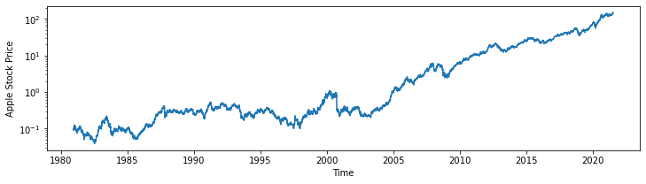

```python
import yfinance as yf

aapl = yf.download("AAPL", data_source='yahoo')['Adj Close']

plt.plot(aapl)
plt.yscale('log')
plt.xlabel('Time')
plt.ylabel('Apple Stock Price')
```

## Time Series Components

*What is within the `appl` series? What is a time series*

```python
aapl.head(5)
```

```
Date
1980-12-12    0.100751
1980-12-15    0.095495
1980-12-16    0.088485
1980-12-17    0.090676
1980-12-18    0.093304
Name: Adj Close, dtype: float64
```

```python
aapl.head(5).index
```

```
DatetimeIndex(['1980-12-12', '1980-12-15', '1980-12-16', '1980-12-17',
               '1980-12-18'],
              dtype='datetime64[ns]', name='Date', freq=None)
```

So in essence, time series in pandas are often just series of data with a time index.

## Pandas and Time Series

*Why is pandas good at handling and processing time series data?*

It has specific tools for resampling and interpolating data:

- See 11.3, 11.5 and 11.6 in PDA textbook

It handles irregular data well:

- missing values
- duplicate entries (`fillna(method='ffill')` or `data.fillna(data.mean())`)

## Datetime in Pandas

*What other uses might time data have?*

We can extract data from datetime columns. These columns have the `dt` and its sub-methods. Example:

```python
dt_ser2 = pd.Series(aapl.index)
dt_ser2.dt.month #also year, weekday, hour, second
```

```
0        12
1        12
2        12
3        12
4        12
         ..
10232     7
10233     7
10234     7
10235     7
10236     7
Name: Date, Length: 10237, dtype: int64
```

Many other useful features (e.g. aggregation over time into means, medians, etc.)